# テキスト分析

機械学習

[川田恵介](https://github.com/tetokawata/TargetML)

keisukekawata@iss.u-tokyo.ac.jp

東京大学

2025-11-05

# テキスト変数

## 非伝統的データ

- データ分析 $=$ 収集された事例から学ぶ方法
  - 事例は”数字”以外でも記録される
  - テキスト: 日本においては少なくとも1500年前から利用 ([稲荷山古墳出土鉄剣](https://ja.wikipedia.org/wiki/%E7%A8%B2%E8%8D%B7%E5%B1%B1%E5%8F%A4%E5%A2%B3%E5%87%BA%E5%9C%9F%E9%89%84%E5%89%A3))
    - 近年はインターネット/SNSの発展もあり大量のテキスト情報が利用可能に
  - 動画/音声/画像: 近年、積極的に利用されている
- 機械学習を応用した分析が主流

## 例: COVID関連論文

- $Y=$ シリアル値 (1900年1月1日を1とした日付の通し番号)、$D=$ 1 (一般向け)、0 (専門家向け)

```r
library(tidyverse)

read_csv("Public/text.csv")
```

```
# A tibble: 264 × 3
       Y     D Title
   <dbl> <dbl> <chr>
 1 44049     1 新型コロナ対策としてのマスク着用義務化――アメリカの政策評価と日本への示唆……
 2 44273     1 現状放置なら５月下旬に緊急事態宣言の恐れ
 3 44105     1 接触確認アプリCOCOAを行動経済学で読み解く
 4 44274     1 新型コロナ対策がもたらす効果の定量的分析～緊急事態宣言解除後のシナリオとは？～……
 5 44028     1 新型コロナ危機と経済政策
 6 44232     1 感染症データにおける「従属性」と因果推論
 7 44018     1 「疫学」と「マクロ経済学」の視点から ―最新論文に見る感染症対策と経済活動維持の最適解とは―……
 8 43929     1 コロナ危機は需要ショックなのか供給ショックなのか？
 9 44029     1 コロナ危機の経済学 : 提言と分析
10 44044     1 新型コロナウイルスのマクロ経済学 (1) 感染症拡大防止政策のトレードオフ……
# ℹ 254 more rows
```

## 例 ワードクラウド

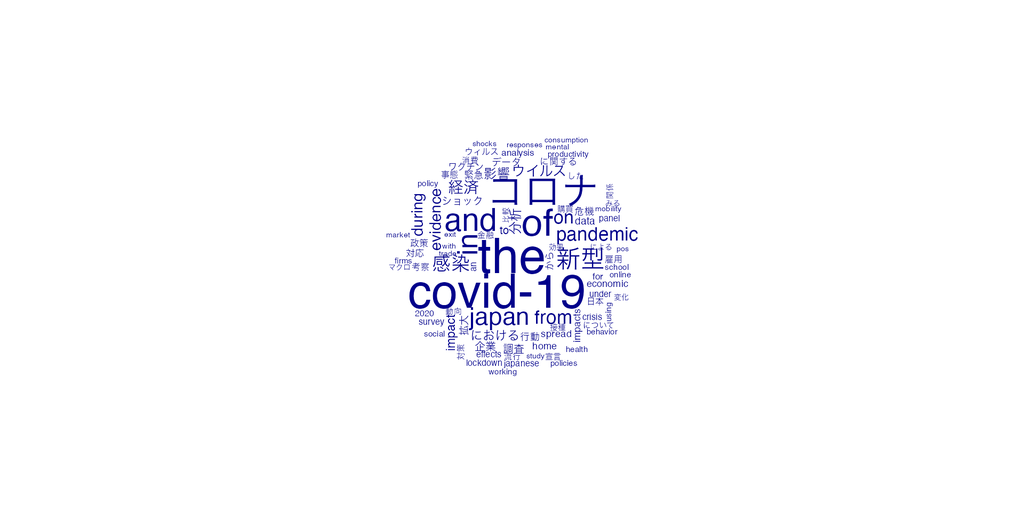

## 例

- 研究のサイクル: 研究発信は、研究者向け (論文等) と一般向け (記事等) $(D)$ に大別できる
  - どちらが先 $(Y)$ に発信されるか?
  - 同じような研究課題の場合は?
    - タイトルの情報 $(X)$ から判断

## 実際の例

- 予測研究: 書類選考への活用
  - エントリーシートの内容 $(X)$ から、「人物像/剽窃の有無」 $(Y)$ などを予測

## 実際の例

- 物価研究: 消費者物価指数
  - “同じような消費生活をする $(X)$”場合に、去年と今年 $(D)$ で必要な費用 $(Y)$ の比較
  - 長年の課題は、商品の質の評価 (ステレス値上げ/品質の改善)
    - 例: PCの値段は、品質を考慮した場合、低下しているかもしれない
- Bajari et al. (2023) : 商品の質を画像やテキストなどから測定

## 個人的経験

- 実務家からの関心をもたれやすい
  - データ分析 $=$ “数値分析”という誤ったイメージのせいで、“利用できないと思われていた情報”が活用できるのは魅力的?
- ここまで学習してきた手法が使えるので、学生時代に、チャレンジしてみるのもおすすめ

# 課題

## 復習: 母平均の推定問題

- 基本: “似ている”複数の事例を集計して、 母平均を推定する
  - 例: 練馬区の物件は”似ている”
- 変数 $X$ の役割 $=$ 似ている事例かどうかの判断基準
  - 統計・機械学習 $=$ データから似ている度を判定する
- 伝統的な$X$ : カテゴリー/連続変数
  - テキスト変数は大きく異なる特徴を持つ

## VS カテゴリー変数

- 性別、国籍、学部など
- “少数”の値しか存在しないのであれば
  - 同じ値をとるサンプルが複数存在
  - 値が同じであれば似ている、異なるのであれば似ていない
- テキスト変数 $=$ 無限大の種類がある

## VS 連続変数

- 年齢、身長など
- 同じ値をとるサンプルは極めて少数だが、
  - 値が近いかどうかは自明
  - 例: 160cmは、190cmよりも、161cmと似ている
- テキスト変数 $=$ テキストが近いとは?

## テキスト変数の難しさ

- テキストは情報が”豊富”すぎるため、変数の値が似ているかどうかが不明確
  - 似ている文章とは？
- 何らかの単純化が必要

# 分析手順

## 前処理

1. $Text$を単純な変数に置き換える (前処理)
2. 大量の$X$に対応した手法で推計 (機械学習の活用)

## 前処理: Token

- テキストを単語の羅列として単純化（Token化）
- 日本語は単語化が難しい
  - 分かち書きをしない
  - quantedaパッケージを用いれば解決可能

## 例: 武蔵大学の印象

| ID | Text |
| --- | --- |
| 1 | キャンパスが綺麗 |
| 2 | 池袋から近い |
| 3 | キャンパスがおしゃれ |

## 例: 武蔵大学の印象

```r
library(tidyverse)

library(quanteda)

corp <- corpus(Example, text_field = "Text")

corp
```

```
Corpus consisting of 3 documents and 1 docvar.
text1 :
"キャンパスが綺麗"

text2 :
"池袋から近い"

text3 :
"キャンパスがおしゃれ"
```

## 例: 武蔵大学の印象

```r
token <- tokens(corp)

token
```

```
Tokens consisting of 3 documents and 1 docvar.
text1 :
[1] "キャンパス" "が"         "綺麗"

text2 :
[1] "池袋" "から" "近い"

text3 :
[1] "キャンパス" "が"         "おしゃれ"
```

## 前処理：Bag of words

- Token化しただけでは、依然として、全ての事例が異なる値を有する
  - さらなる単純化が必須
- 代表的な手法は、 Bag of words
  - 単語の出現頻度を数える
- 文脈や語順は捨象
  - 発展: N-gram, word-embedding

## 例: 武蔵大学の印象

```r
dfm <- dfm(token)

convert(dfm, "matrix")
```

```
       features
docs    キャンパス が 綺麗 池袋 から 近い おしゃれ
  text1          1  1    1    0    0    0        0
  text2          0  0    0    1    1    1        0
  text3          1  1    0    0    0    0        1
```

- “単語を変数とする”データに加工

## 頻度分析

- どのような単語が使われているか
  - グループごとに集計も可能
  - テキスト分析版、記述統計分析

## 頻度

```r
topfeatures(dfm)
```

```
キャンパス         が       綺麗       池袋       から       近い   おしゃれ
         2          2          1          1          1          1          1
```

## ワードクラウド

```r
library(quanteda.textplots)

textplot_wordcloud(dfm, 20,min_count = 1)
```

[figure not shown]

# 線型予測モデル

## テキストによる予測

- $Y\sim テキスト$ を推定する
- 変数の数が多すぎて(事例数を超える)、伝統的な手法は一般に機能しない
  - テキスト分析が難しかった理由
  - LASSOなどの大量の変数に対応した手法を活用

## OLSの前提条件

- 複雑なモデルの推定に向いてない
  - 変数数 $>$ 事例数であれば、原理的に推定できない
    - テキスト分析ではしばしば発生する

## LASSO

- 複雑なモデルの推定に向く
  - 変数数 $>$ 事例数でも推定できる

## 実例: LASSO

- 効果年を予測する単語

```r
Model = hdm::rlasso(
  y = data$Y,
  x = X, # テキストを加工した変数
  post = FALSE
)

Coef= coef(Model)[-1]

Coef[Model$index == TRUE]
```

```
     コロナ          を          は    ショック         pos        購買
-74.7745061 -12.6727723  -0.1227596  -0.8245517 -89.5733217 -95.8838353
         in     effects
  6.5622978   2.7902845
```

## 実例: 二重選択

- 効果年を予測する単語

```r
Model = hdm::rlassoEffect(
  y = data$Y,
  d = data$D,
  x = X # テキストを加工した変数
)

confint(Model)
```

```
       2.5 %    97.5 %
d1 -261.2084 -149.1888
```

## 実例: 単純比較

```r
estimatr::lm_robust(Y ~ D, data)
```

```
              Estimate Std. Error   t value     Pr(>|t|)   CI Lower   CI Upper
(Intercept) 44304.6651   12.48143 3549.6472 0.000000e+00 44280.0884 44329.2417
D            -228.0651   19.71466  -11.5683 2.813002e-25  -266.8844  -189.2457
             DF
(Intercept) 262
D           262
```

## Takeaway

- テキストを $X$ として用いる方法については、多くの議論が蓄積されている
  - $Y$ ないし $D$ として用いる方法は、より難しい
- 基本的なアイディアは、(1) 前処理によりある程度単純化、 (2) 大量の変数を扱える方法で推定
  - 本スライドでは、シンプルな方法 (bug of words)を紹介

## Reference

Bajari, Patrick, Zhihao Cen, Victor Chernozhukov, Manoj Manukonda, Suhas Vijaykumar, Jin Wang, Ramon Huerta, et al. 2023. “Hedonic Prices and Quality Adjusted Price Indices Powered by AI.” *arXiv Preprint arXiv:2305.00044*.